# Lab 10: Filtering Data

## Pick a dataset

Today you will again have a choice of three data sets to work with.

Metadata from US senator’s tweets:

Pick a data set (feel free to delete the others from the Rmd file if you would like), and work on the instructions in the next section.

## Instructions

This lab is similar to the last. You’ll pick a dataset and then generate an analysis of that data using data visualizations. The difference here is that instead of a single plot, I would like you to construct 3-4 plots that together tell a linear story. Each plot should be separated by a sentence or two describing what the viewer should take away from the plot. Try to keep the plots similar in some way; perhaps each simply highlights a different subset of the data but has the same underlying layers.

Notice that each of the datasets for today are larger than you will probably be able to use. You will need to filter the data to a particular team, year, subset of curse words. You may further filter the data to highlight an even smaller subset of the data within each plot.

## Analysis

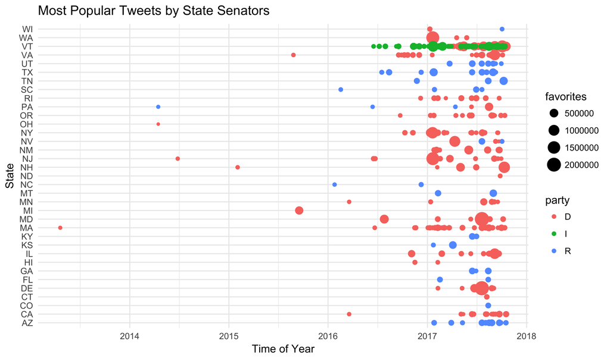

This plot displays the amount of tweets per state and how popular they are based on the size of the point. From this data, one can conclude that there are significantly more Democratic Senators and conclude which states are mainly Democratic or Republican. This data also clearly shows us that Vermont has the only independent Senator.

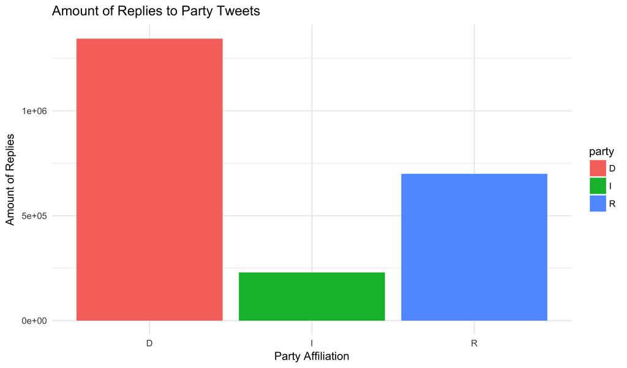

From this plot, the viewer should take away that Democratic tweets get more replies than the other parties. This can be attributed tot he fact that there are also more Democratic Senators.

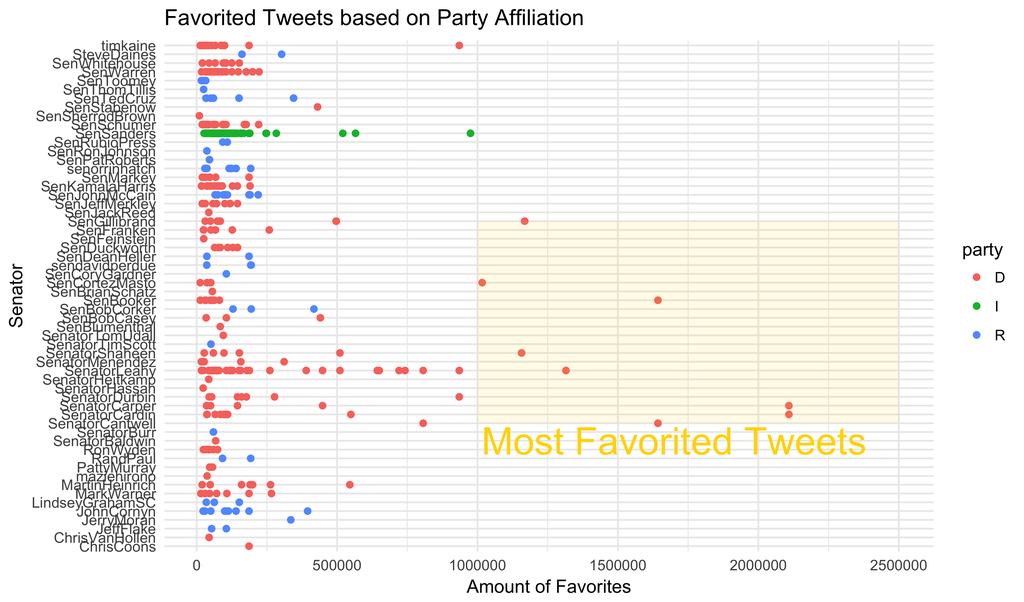

This plot should tell the viewer which senators have the most popular tweets based on how many favorites they get. Democratic senators lead the pack in having the most Favorited tweets.